# Processing, analyzing, and interpreting epigenome-wide DNA methylation data

Andrea Baccarelli, Andres Cardena, Elena Colicino, Jonathan Heiss, Allan Just

June, 2019

Local library

```r
.libPaths("C:/EBC4/Rpackages")
```

## Importing the data

1. Read in the file `data/pheno.csv` using `fread` from the data.table package, save it as object named `pheno`.
2. Import the methylation data using the function `read_idats`. You only have to provide the first part of the file name without the `_Red.idat.gz` or `_Grn.idat.gz` suffixes.
3. Save as object named `meth`

```r
pheno = fread("data/pheno.csv")
meth = read_idats("data/" %s+% pheno$gsm,quiet=TRUE)
```

[output not shown]

Take a look at the dataset

```r
# The name of the platform (450K/EPIC)
meth$platform
```

```
## [1] "450K"
```

A manifest with probe IDs, color channel, genomic coordinates and other important information

```r
meth$manifest[4000:4010]
```

```
##       probe_id addressU addressM channel next_base chr mapinfo strand
##  1: cg15483381 45788508       NA    Both             1 3421427      F
##  2: cg10331884 38625424       NA    Both             1 3421598      F
##  3: cg03448635 43649416       NA    Both             1 3424354      R
##  4: cg04439600 63754435       NA    Both             1 3424477      R
##  5: cg01215682 68770379       NA    Both             1 3424530      F
##  6: cg21108519 26774468       NA    Both             1 3425603      R
##  7: cg02631196 48787476       NA    Both             1 3425761      R
##  8: cg03313659 29635505 69795504     Grn         C   1 3425777      R
##  9: cg03457400 70638320       NA    Both             1 3426236      F
## 10: cg08036524 36768369 13625334     Red         A   1 3426422      R
## 11: cg21212196 46735307       NA    Both             1 3426521      R
##     probe_type index OOBi     Ui     Mi
##  1:         cg  4000   NA 346583 346583
##  2:         cg  4001   NA 272500 272500
##  3:         cg  4002   NA 322922 322922
##  4:         cg  4003   NA 518693 518693
##  5:         cg  4004   NA 564983 564983
##  6:         cg  4005   NA 163054 163054
##  7:         cg  4006   NA 376116 376116
##  8:         cg  4007  438 185892 574964
##  9:         cg  4008   NA 577284 577284
## 10:         cg  4009 1000 259880  30027
## 11:         cg  4010   NA 353819 353819
```

Please note that Type I probes have `addressU` and `addressM` (two different beads), whereas Type II probes only have a single `addressU` Most of the probes are of Type II

```r
table(meth$manifest$channel)
```

```
##
##   Both    Grn    Red
## 350076  46298  89203
```

Not all probes are targeting CpG sites

```r
table(meth$manifest$probe_type)
```

```
##
##     cg     ch     rs
## 482421   3091     65
```

Similar manifest for the control probes

```r
head(meth$controls)
```

```
##     address    group channel          name index      i
## 1: 21630339 STAINING     -99      DNP(20K)     1     NA
## 2: 27630314 STAINING     Red    DNP (High)     2 165943
## 3: 43603326 STAINING  Purple     DNP (Bkg)     3 320778
## 4: 41666334 STAINING   Green Biotin (High)     4 304106
## 5: 24669308 STAINING     -99    Biotin(5K)     5     NA
## 6: 34648333 STAINING    Blue  Biotin (Bkg)     6 234885
```

Also included

```r
# Matrices contained fluorescence intensities for the methylated (`M`) and unmethylated (`U`) signals
dim(meth$M)
```

```
## [1] 485577     35
```

```r
meth$U[201:203,1:3]
```

```
##       [,1]  [,2]  [,3]
## [1,] 14051 11767 13847
## [2,] 13840 12979 15744
## [3,] 12716 13757 11530
```

```r
meth$M[201:203,1:3]
```

```
##      [,1] [,2] [,3]
## [1,]  513 1071  518
## [2,] 1127 1463 1944
## [3,]  232  348  179
```

Matrices with the bead copy number (`N` and `V`)

```r
dim(meth$N)
```

```
## [1] 485577     35
```

```r
meth$N[201:203,1:3]
```

```
##      [,1] [,2] [,3]
## [1,]   13   14    9
## [2,]    5   14   19
## [3,]    7    7   13
```

For some beads the copy number is zero. Because of the random assembly some did not end up on the chips

```r
colSums(meth$N==0)
```

```
##  [1] 424 216  10 337 658 213  16   6 332   3 432 171  90  95   2 172   7
## [18] 170  39 275 348  10   3   6 216 437  56 594  42  17  13 180  29  10
## [35]   1
```

Matrices with the out-of-band intensities

```r
dim(meth$oobG$M) # same number as Type I red probes
```

```
## [1] 89203    35
```

```r
dim(meth$oobR$U)
```

```
## [1] 46298    35
```

Some meta data

```r
head(meth$meta)
```

```
##     sample_id       date     time
## 1: GSM2260480 2012-10-18 16:14:50
## 2: GSM2260482 2012-01-19 17:14:44
## 3: GSM2260485 2014-03-05 21:29:37
## 4: GSM2260486 2012-01-19 17:17:29
## 5: GSM2260487 2012-10-18 15:20:27
## 6: GSM2260488 2012-10-18 14:16:58
```

# Quality control

## Control metrics

```r
meth %>% control_metrics %>% sample_failure -> pheno$failed
# Alternative syntax:
# pheno$failed = sample_failure(control_metrics(meth))

table(pheno$failed,useNA='ifany')
```

```
##
## FALSE
##    35
```

There are no failed samples.

## Sex check

1. Apply the function `check_sex` on the `meth` object to compute the normalized average total fluorescence intensity of probes targeting the X and Y chromosomes.
2. Use the function `predict_sex` to infer the sex of the sample donors from the methylation data.
3. Add column `predicted_sex` to `pheno`
4. Are there samples where `sex != predicted_sex`? What is the sample ID?
5. Flag the problematic samples with a logical variable `exclude` in `pheno`

```r
pheno[,c("X","Y"):=check_sex(meth)]

pheno$predicted_sex = predict_sex(pheno$X,pheno$Y,which(pheno$sex=="m"),which(pheno$sex=="f"))

pheno[sex!=predicted_sex]
```

```
##           gsm sex     smoker failed        X         Y predicted_sex
## 1: GSM2260573   f non-smoker  FALSE 0.760684 0.8479393             m
```

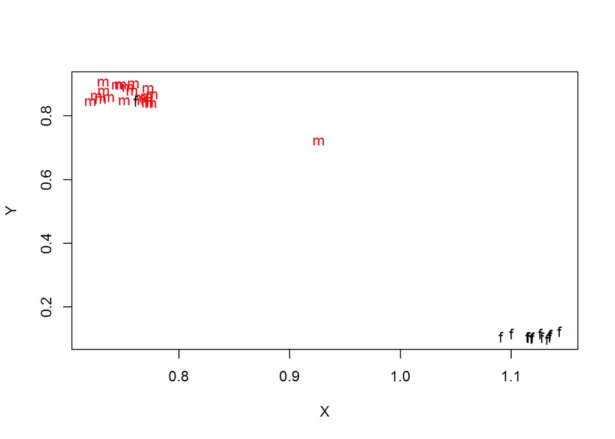

```r
plot(Y~X,data=pheno,type="n")
text(Y~X,labels=sex,col=ifelse(sex=="m",2,1),data=pheno)
```

```r
pheno[,exclude:=FALSE]

pheno[sex!=predicted_sex,.(gsm,sex,predicted_sex)]
```

```
##           gsm sex predicted_sex
## 1: GSM2260573   f             m
```

```r
pheno[sex!=predicted_sex,exclude:=TRUE] # flag sample
```

## Detection p-values

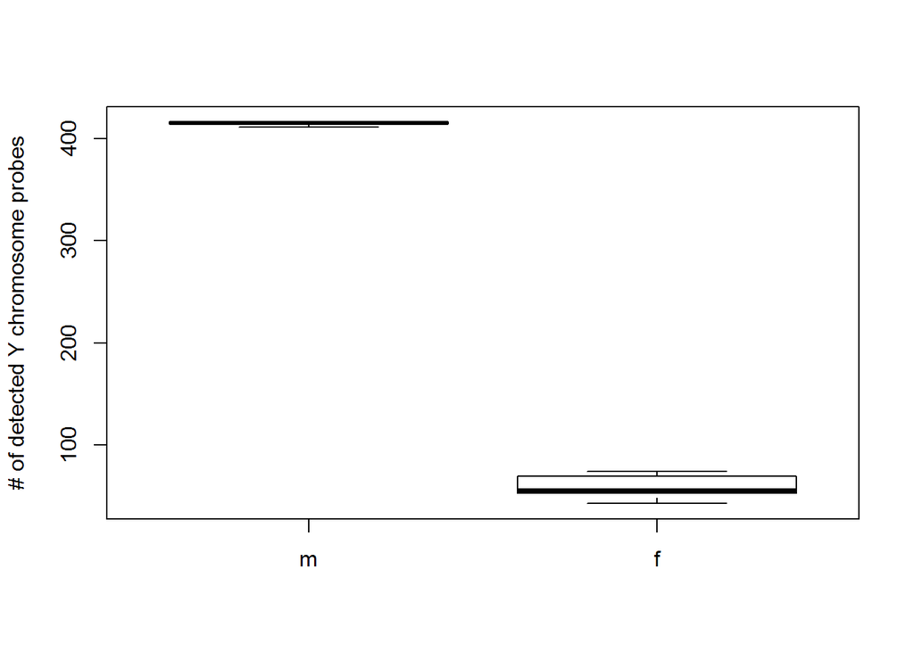

```r
meth = ewastools::detectionP(meth)
chrY = meth$manifest[chr=='Y',index]
detP = meth$detP[chrY,]
detP = colSums(detP<0.01,na.rm=TRUE)

boxplot(split(detP,pheno$predicted_sex),ylab="# of detected Y chromosome probes")
```

```r
split(detP,pheno$predicted_sex) %>% sapply(mean)
```

```
##         m         f
## 414.77273  59.53846
```

Almost all of the 416 chromosome probes are called detected in male samples, for female samples on average 60 are called detected. How many probes are undetected (not counting the Y chromosome). The cut-off used here is 0.01

```r
meth$detP[-chrY,] %>% is_weakly_greater_than(0.01) %>% table(useNA="ifany")
```

```
## .
##    FALSE     TRUE     <NA>
## 16939303    33749     7583
```

Less than 0.2% are undetected

```r
round((33749/(33749+16939303))*100,3)
```

```
## [1] 0.199
```

We should mask these undetected probes.

```r
meth = ewastools::mask(meth,0.01)
```

## Dye-bias correction

Infinium BeadChips use two fluorescent dyes that are linked to the nucleotides used in the the single-base extension step. A and T nucleotides use are linked with a red dye (the red color channel), G and C nucleotides are linked with a green dye (green color channel). Uncorrected data usually feature higher intensities in the red color channel, the so-called dye bias. For probes of Infinium type II design, which use separate color channels to measure the methylated and unmethylated signal, this results in a shifted distribution of beta-values. (Probes of Infinium design type I are not affected, as they measure both signals in the same color channel.) Dye-bias correction normalizes the red and green color channel. `ewastools` provides an improved version of RELIC ([Xu et al., 2017](https://doi.org/10.1186/s12864-016-3426-3)) using robust Theil-Sen estimators.

```r
color_bias = meth %>% dont_normalize
beta       = meth %>% correct_dye_bias %>% dont_normalize
```

We can look at a few methylation values on the fly and see whether dye-bias correction changed them

```r
meth$manifest$channel[201:203] # One probe for each type/color channel
```

```
## [1] "Both" "Red"  "Grn"
```

```r
color_bias[201:203,1:3] %>% round(4)
```

```
##            GSM2260480 GSM2260482 GSM2260485
## cg27487046     0.0352     0.0834     0.0361
## cg06091566     0.0753     0.1013     0.1099
## cg03735847     0.0179     0.0247     0.0153
```

```r
beta      [201:203,1:3] %>% round(4)
```

```
##            GSM2260480 GSM2260482 GSM2260485
## cg27487046     0.0196     0.0437     0.0210
## cg06091566     0.0753     0.1013     0.1099
## cg03735847     0.0089     0.0139     0.0069
```

If we calculate beta-values from raw data, we can observe the dye bias as a deviation of the beta-values for heterozygous SNPs from 0.5

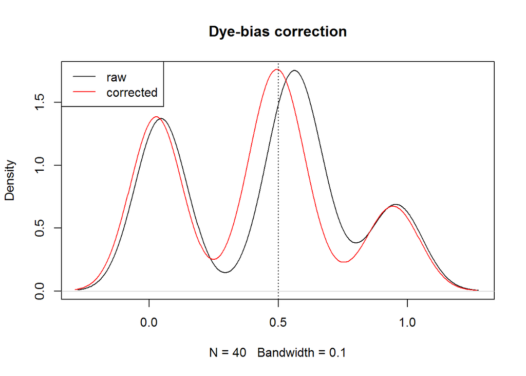

```r
snps = meth$manifest[probe_type=="rs" & channel=="Both"]$index

plot (density(color_bias[snps,14],na.rm=TRUE,bw=0.1),col=1,main="Dye-bias correction")
lines(density(beta      [snps,14],na.rm=TRUE,bw=0.1),col=2)
abline(v=0.5,lty=3)
legend("topleft",col=1:2,legend=c("raw","corrected"),lwd=1)
```

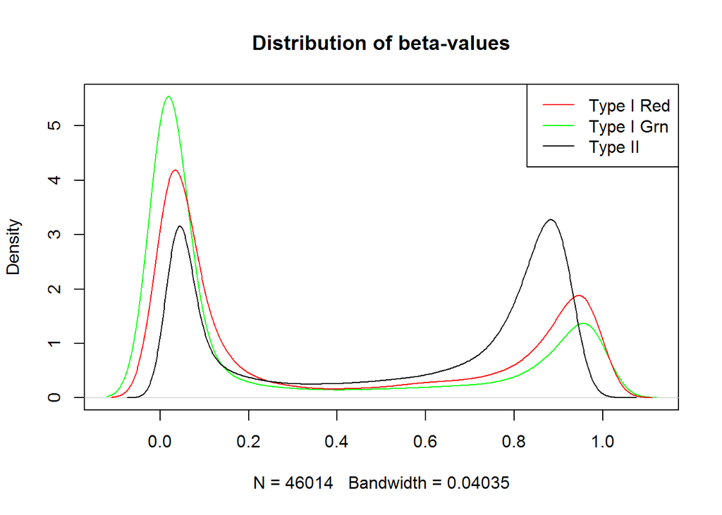

```r
plot (density(beta[meth$manifest$channel=="Grn" ,1],na.rm=TRUE),col="green",main="Distribution of beta-values")
lines(density(beta[meth$manifest$channel=="Red" ,1],na.rm=TRUE),col="red")
lines(density(beta[meth$manifest$channel=="Both",1],na.rm=TRUE),col="black")
legend("topright",legend=c("Type I Red","Type I Grn","Type II"),lwd=1,col=c("red","green","black"))
```

## SNP outliers

`snp_outliers()` returns the average log odds of belonging to the outlier component across all SNP probes. I recommend to flag samples with a score greater than -4 for exclusion.

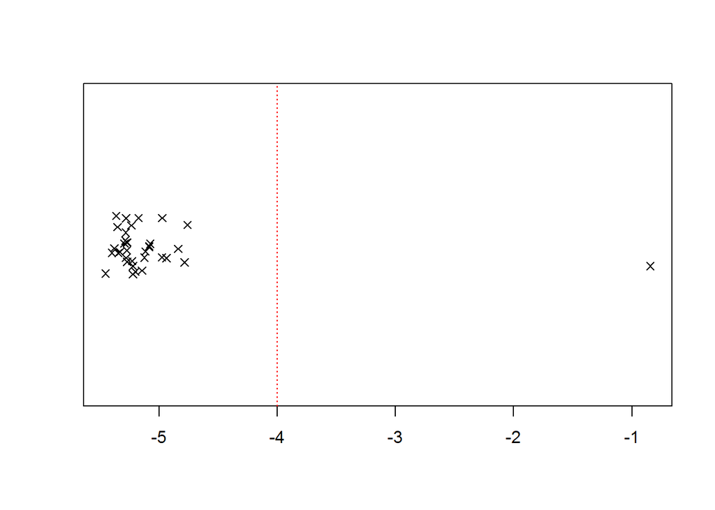

```r
snps = meth$manifest[probe_type=="rs"]$index
genotypes = call_genotypes(beta[snps,],learn=FALSE)
pheno$outlier = snp_outliers(genotypes)

stripchart(pheno$outlier,method="jitter",pch=4)
abline(v=-4,lty="dotted",col=2)
```

```r
pheno[outlier>-4]
```

```
##           gsm sex smoker failed         X         Y predicted_sex exclude
## 1: GSM2260653   m smoker  FALSE 0.9266193 0.7212944             m   FALSE
##       outlier
## 1: -0.8460863
```

```r
pheno[outlier>-4,exclude:=TRUE]
```

The one sample failing this check is the same sample that did not belong to either the male or female cluster in the plot above. This is strong evidence that this sample is indeed contaminated. While SNP outliers can also result from poorly performing assays, the sample passed the first quality check looking at the control metrics, therefore rendering this possibility unlikely. Another cause for a high outlier score is sample degradation (e.g., FFPE samples).

```r
pheno$donor_id = enumerate_sample_donors(genotypes)
pheno[,n:=.N,by=donor_id]
pheno[n>1,.(gsm,donor_id)]
```

```
##           gsm donor_id
## 1: GSM2260485        3
## 2: GSM2260543        3
```

```r
pheno[gsm=="GSM2260543",exclude:=TRUE] # drop duplicate
```

## Principal component analysis

Principal component analysis is a popular feature reduction method: it projects high-dimensional data into a lower-dimensional representation while trying to retain as much variability as possible. This is especially useful when either individual features are highly correlated and it is therefore reasonable to summarize them, or when (sometimes subtle) traces of background effects can be found across of large number of features. 1. Get of subset of beta without probes on the X and Y chromosome

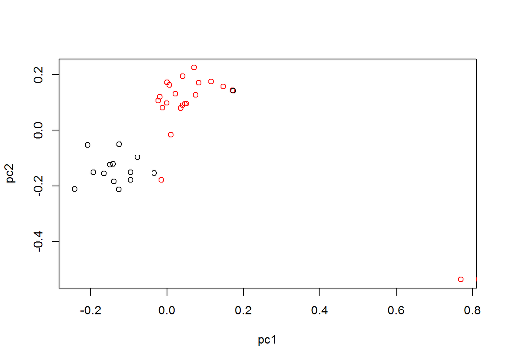

```r
chrXY = meth$manifest$chr %in% c("X","Y") | meth$manifest$probe_type == "rs"
pcs = beta[-chrXY,]
pcs = pcs - rowMeans(pcs)
pcs = na.omit(pcs)
pcs = t(pcs)
pcs = trlan.svd(pcs,neig=2)
pcs = pcs$u

pheno$pc1 = pcs[,1]
pheno$pc2 = pcs[,2]

plot(pc2~pc1,col=ifelse(sex=="m",2,1),data=pheno)
text(pc2~pc1,labels=pheno[34]$gsm,data=pheno[34],pos=4,offset=1,col=2)
```

```r
pheno[gsm=="GSM2219539",exclude:=TRUE]
```

GSM2219539 is actually a lung tissue sample from another GEO dataset. It dominates the first principal component and should be excluded as it otherwise could drastically change the results of downstream analyses. PCA may be applied iteratively. After excluding samples that manifest as outliers, repeating PCA can give very different principal components.

## Leukocyte composition

This quality check will only apply in case of blood samples (blood is, however, one of the most commonly studied tissues). The function `estimateLC()` implements the [Houseman method](https://doi.org/10.1186/1471-2105-13-86) to predict the leukocyte composition. The user has the choice between various sets of model parameters trained on various reference datasets (see `?estimateLC` for a list of options). The function operates on the matrix of beta-values.

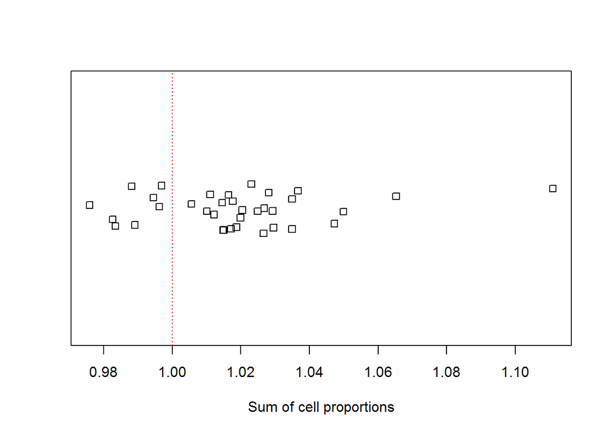

```r
LC = estimateLC(beta,ref="Reinius")

stripchart(rowSums(LC),xlab="Sum of cell proportions",m="jitter")
abline(v=1,lty=3,col=2)
```

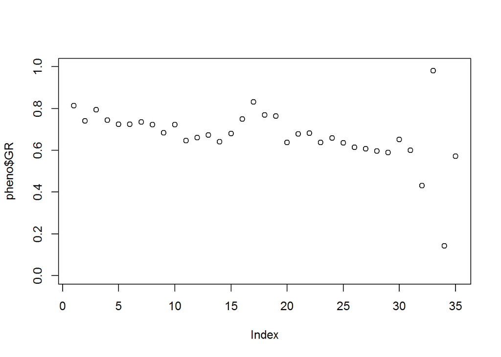

```r
pheno = cbind(pheno,LC)

plot(pheno$GR,ylim=c(0,1))
```

```r
pheno[which.min(GR),.(gsm,exclude)]
```

```
##           gsm exclude
## 1: GSM2219539    TRUE
```

This is the lung tissue sample from before

```r
pheno[which.max(GR),.(gsm,exclude)]
```

```
##           gsm exclude
## 1: GSM1185585   FALSE
```

This is actually a sample of purified granulocytes

```r
pheno[gsm=="GSM1185585",exclude:=TRUE]
```

LC stratified by smoking status

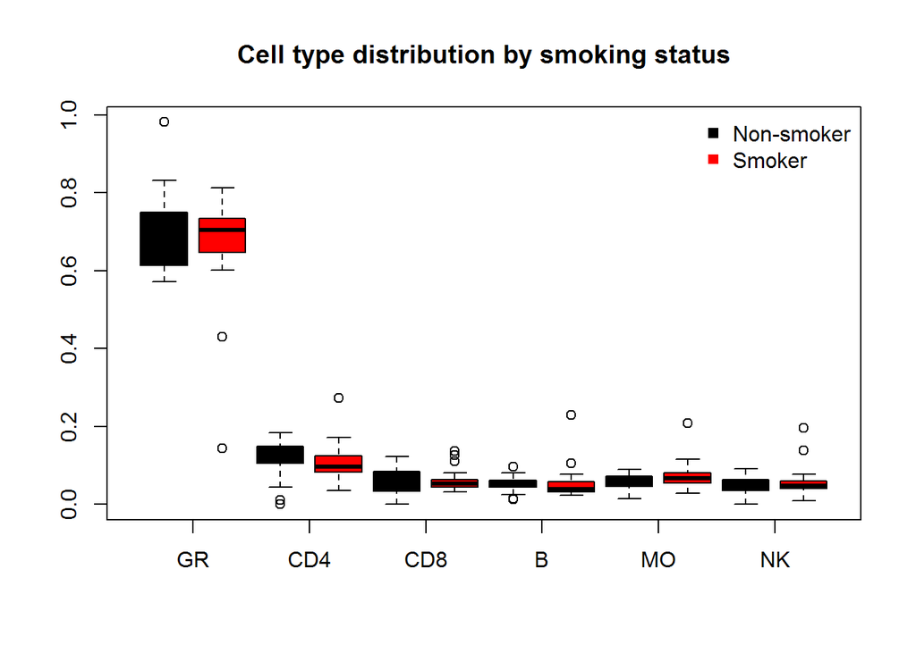

```r
LC$smoker = pheno$smoker
LC = melt(LC,value.name="proportion",variable.name="cell_type",id.vars="smoker")

boxplot(proportion ~ smoker+cell_type,LC,col=1:2,main="Cell type distribution by smoking status",xaxt="n")
axis(1,at=seq(from=1.5, to=11.5,by=2),adj=1,labels=unique(LC$cell_type))
legend("topright",c("Non-smoker","Smoker"),pch=15,bty='n',col=1:2)
```

```r
# drop problematic samples
keep = which(!pheno$exclude)

# drop columns no longer needed
pheno = pheno[,.(gsm,smoker,sex,CD4,CD8,NK,MO,GR,B)]

# write data to disk
pheno = pheno[keep]
beta  = beta[,keep]
manifest = copy(meth$manifest)

save(pheno,manifest,beta,file="data/processed.rda")
```